[figure not shown]

# Active Lives Children and Young People Survey

Somerset and England · 2024/25 · Working draft

## Executive summary

[figure not shown]

**About the data and how to use this report**

These are weighted estimates from Sport England’s Active Lives Survey. Each measure uses eligible respondents with valid answers and an approved positive weight.

Select Somerset, England or both; select groups; switch between current-year charts, trends and tables. Download PNG saves the displayed chart. England uses blue shades, hatched bars and dashed trend lines.

For wellbeing and motivation, choose whether percentages are calculated within each response category or within each activity group. Filtering visible groups does not recalculate denominators.

Changes are descriptive and are not significance tests. Missing values are not zero.

In 2024/25, **49.9%** were active in Somerset, compared with **49.1%** in England.

The local active percentage changed by **+5.7 percentage points** from 2023/24 (44.2%). This is a descriptive comparison.

## Levels of activity

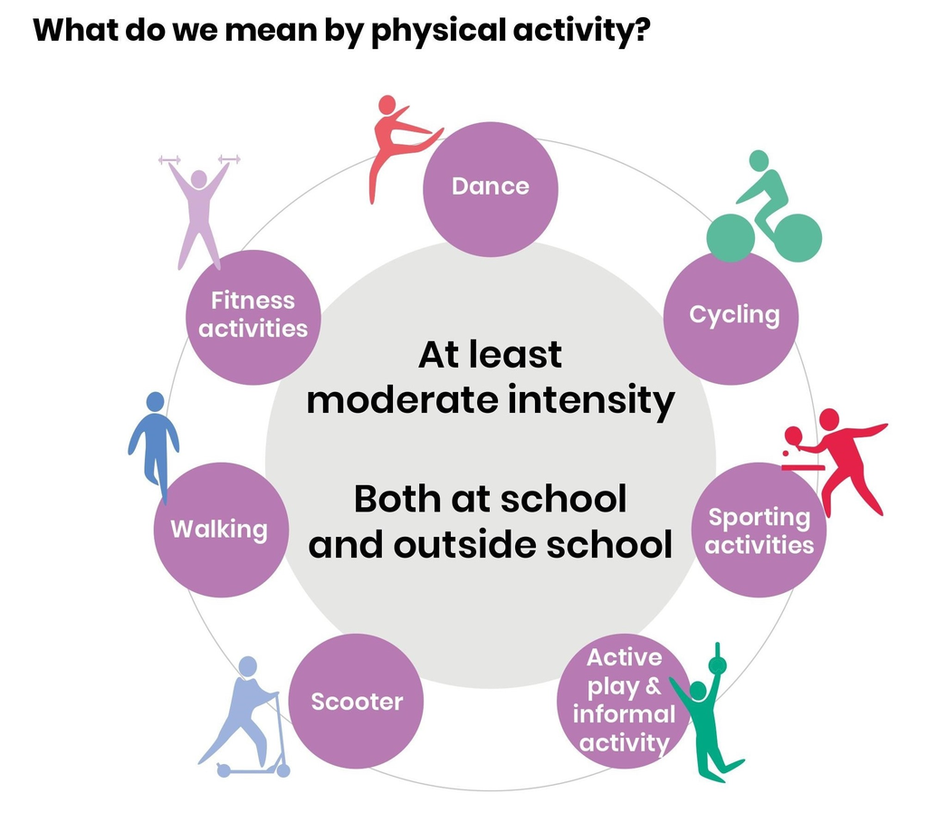

**Overall activity**

**Overall activity by Gender**

**Overall activity by School year**

**Overall activity by Family affluence**

**Overall activity by Disability**

**Overall activity by Ethnicity**

## Types of activity

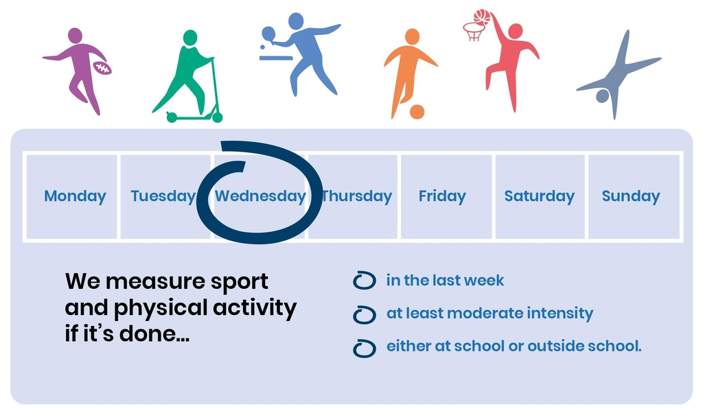

**Participation by activity type**

Participated once a week or more. Each activity is a separate measure; percentages do not sum to 100%.

**Swimming 25 metres unaided**

**Swimming 25 metres unaided by Gender**

**Swimming 25 metres unaided by School year**

**Swimming 25 metres unaided by Family affluence**

**TRAVEL TO SCHOOL MODE: CAR**

**TRAVEL TO SCHOOL MODE: ACTIVE**

**TRAVEL TO SCHOOL MODE: PUBLIC TRANSPORT**

## Wellbeing and development

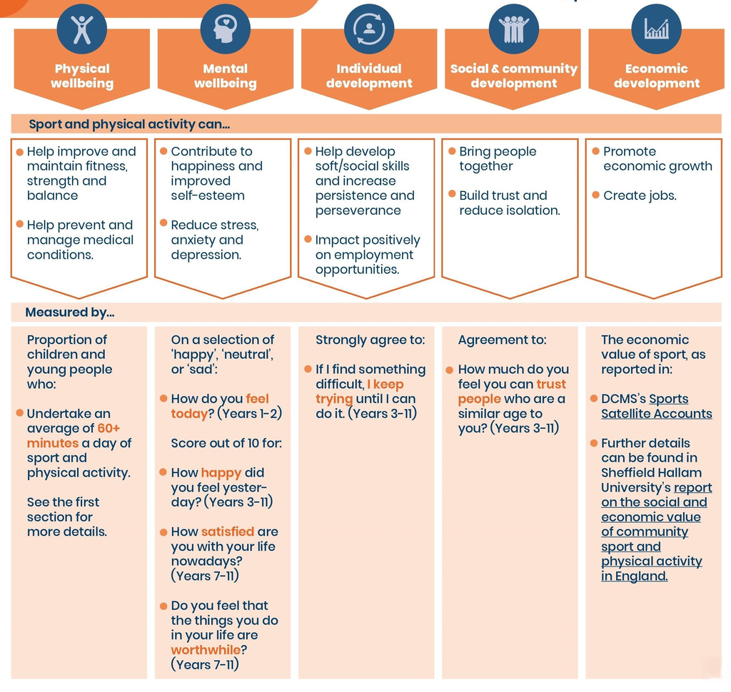

**Loneliness: frequency**

**Loneliness: frequency and activity level**

**Loneliness: frequency and activity level**

**Often or always lonely**

**Often or always lonely and activity level**

**Often or always lonely and activity level**

**Happiness**

**Happiness and activity level**

**Happiness and activity level**

**Life satisfaction**

**Life satisfaction and activity level**

**Life satisfaction and activity level**

**Feeling worthwhile**

**Feeling worthwhile and activity level**

**Feeling worthwhile and activity level**

**Resilience**

**Resilience and activity level**

**Resilience and activity level**

**Trust**

**Trust and activity level**

**Trust and activity level**

## Attitudes and opportunities

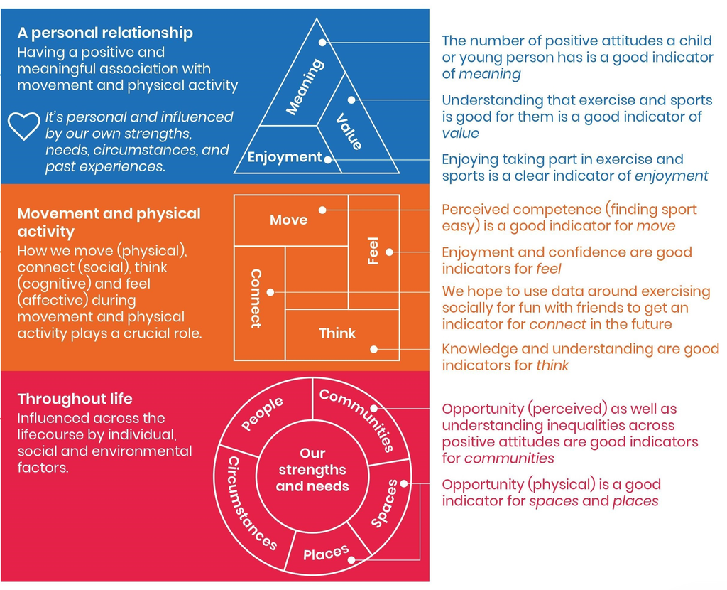

**I find exercise and sports easy (Strong agreement, can't say as missing answer)**

**I find exercise and sports easy (Strong agreement, can't say as missing answer) and activity level**

**I find exercise and sports easy (Strong agreement, can't say as missing answer) and activity level**

**I enjoy taking part in exercise and sports (Strong agreement, can't say as missing answer)**

**I enjoy taking part in exercise and sports (Strong agreement, can't say as missing answer) and activity level**

**I enjoy taking part in exercise and sports (Strong agreement, can't say as missing answer) and activity level**

**I feel confident when I exercise and play sports (Strong agreement, can't say as missing answer)**

**I feel confident when I exercise and play sports (Strong agreement, can't say as missing answer) and activity level**

**I feel confident when I exercise and play sports (Strong agreement, can't say as missing answer) and activity level**

**I know how to get involved and improve my skills in lots of different types of exercise and sports :**

**I know how to get involved and improve my skills in lots of different types of exercise and sports : and activity level**

**I know how to get involved and improve my skills in lots of different types of exercise and sports : and activity level**

**I understand why exercise and sports are good for me (Strong agreement, can't say as missing answer)**

**I understand why exercise and sports are good for me (Strong agreement, can't say as missing answer) and activity level**

**I understand why exercise and sports are good for me (Strong agreement, can't say as missing answer) and activity level**

**Access to outdoor spaces for exercise or play: overall**

**Access to outdoor spaces for exercise or play: overall and activity level**

**Access to outdoor spaces for exercise or play: overall and activity level**

## Volunteering

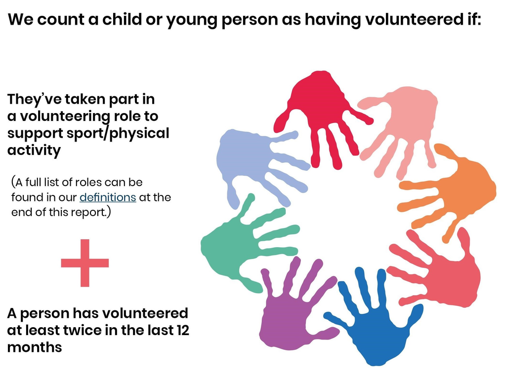

**Volunteering twice in the last 12 months**

Not currently available in this dataset; historical results are retained. This does not confirm that the survey question was discontinued. See data notes.

## Definitions, data notes and sources

**Definitions and interpretation**

Percentages may not sum to 100% because of rounding. Filter selections do not change denominators. Breakdown percentages use respondents with valid answers to both questions and the outcome question’s weight.

Small cells and complementary cells are suppressed. For the two-way activity comparisons, if either view requires suppression, both views for that indicator, area and year are withheld to protect the same underlying cells.

Confidence intervals are not presented because verified intervals are available for only a limited subset of results.

**Survey changes and measure availability**

**2020/21;2021/22:** Standard family-affluence comparisons are omitted for these years. An adjusted scale excluding holidays was used during the pandemic; it is not substituted for the standard scale here. cyp_2023

**2019/20;2020/21;2021/22;2022/23;2023/24:** The disability question was updated from 2019/20. Comparisons with earlier years should take the question change into account. cyp_2019

**2023/24:** The Year 7-11 gender question wording changed in 2023/24, including a non-binary option and prefer-to-self-describe wording. The supplied grouped GEND3 dictionary still labels category 3 as Other; the pipeline preserves that grouped coding. cyp_2023

**2023/24:** State and independent schools were weighted together for the first time in 2023/24. Use the supplied annual weight; a constant weight name does not imply an unchanged weighting method. cyp_2023

**2019/20:** 2019/20 volunteering covers school years 5-11. VolN_bc_POP was verified in the directly shared SPSS file: 1 = Yes, 2 = No; -99, -98 and -91 are excluded as missing. The earlier dictionary-based availability gap has been resolved. cyp_2019

**2019/20:** No 2019/20 outdoor-access estimates: all 89,303 records in the directly shared file are coded -92 (question not asked in this survey year or term). cyp_2019

**2019/20:** Cluster field verified in the directly shared file: 89,303 records, no missing values, 1,341 distinct clusters. cyp_2019

**2020/21:** Cluster field verified in the directly shared file: 86,828 records, no missing values, 1,348 distinct clusters. cyp_2020

**2021/22:** Five-category loneliness response restored from the directly shared file. Codes 1-5 included; code 6 (Prefer not to say) and negative missing codes excluded. cyp_2021

**2021/22:** Exercise ease restored from the directly shared file. Codes 1-2 included; code 99 (Can't say) and negative missing codes excluded. cyp_2021

**2021/22:** Weekly dance participation restored from the directly shared file. Codes 1-2 included; negative missing codes excluded. cyp_2021

**2019/20: Volunteering twice in the last 12 months.** 2019/20 volunteering covers school years 5-11. VolN_bc_POP was verified in the directly shared SPSS file: 1 = Yes, 2 = No; -99, -98 and -91 are excluded as missing. The earlier dictionary-based availability gap has been resolved.

**2019/20: Access to outdoor spaces for exercise or play: overall.** No 2019/20 outdoor-access estimates: all 89,303 records in the directly shared file are coded -92 (question not asked in this survey year or term).

**2019/20: Copy of LAURN for cluster - for datasets containing Local Authority.** Cluster field verified in the directly shared file: 89,303 records, no missing values, 1,341 distinct clusters.

**2020/21, 2021/22: Family affluence.** Standard FAS comparisons omitted for 2020/21 and 2021/22: pandemic restrictions affected the holidays item. Adjusted FAS is not substituted. CYP 2023/24 guide, Table 8 (Family Affluence Scale).

**2020/21: Copy of LAURN for cluster - for datasets containing Local Authority.** Cluster field verified in the directly shared file: 86,828 records, no missing values, 1,348 distinct clusters.

**2021/22: Loneliness: frequency.** Five-category loneliness response restored from the directly shared file. Codes 1-5 included; code 6 (Prefer not to say) and negative missing codes excluded.

**2021/22: I find exercise and sports easy (Strong agreement, can't say as missing answer).** Exercise ease restored from the directly shared file. Codes 1-2 included; code 99 (Can't say) and negative missing codes excluded.

**2021/22: Once a week participation in moderate plus activity: Everywhere: All activities: GROUPED Dance : (CA170).** Weekly dance participation restored from the directly shared file. Codes 1-2 included; negative missing codes excluded.

**2024/25: Gender; Ethnicity; School year; School year (3 groups); Disability; Number of impairments / disabilities; Family affluence; Loneliness: frequency; Often or always lonely; Happiness; Life satisfaction; Feeling worthwhile; Resilience; Trust; I find exercise and sports easy (Strong agreement, can't say as missing answer); I enjoy taking part in exercise and sports (Strong agreement, can't say as missing answer); I feel confident when I exercise and play sports (Strong agreement, can't say as missing answer); I understand why exercise and sports are good for me (Strong agreement, can't say as missing answer); Overall activity; Once a week participation in moderate plus activity: Everywhere: All activities: GROUPED Active Travel : (CA210); Once a week participation in moderate plus activity: Everywhere: All activities: GROUPED Active play : (CA140); Once a week participation in moderate plus activity: Everywhere: All activities: GROUPED Going on a walk : (CC002); Once a week participation in moderate plus activity: Everywhere: All activities: GROUPED Dance : (CA170); Once a week participation in moderate plus activity: Everywhere: All activities: GROUPED Swimming, diving and water polo : (CB156); Once a week participation in moderate plus activity: Everywhere: All activities: GROUPED Team sports : (CB151); Once a week participation in moderate plus activity: Everywhere: All activities: GROUPED Running, athletics or multi-sports : (CB154); Swimming 25 metres unaided; TRAVEL TO SCHOOL MODE: CAR; TRAVEL TO SCHOOL MODE: ACTIVE; TRAVEL TO SCHOOL MODE: PUBLIC TRANSPORT; Access to outdoor spaces for exercise or play: overall.** 2024/25: coding checked against supplied SPSS metadata. Uses wt_grossCCLA from supplied LA complex-samples plan.

**2024/25: I know how to get involved and improve my skills in lots of different types of exercise and sports :.** 2024/25: coding checked against supplied SPSS metadata. Uses wt_grossCCLA from supplied LA complex-samples plan. Derived from PL_Know_c_ans: 1 strongly agrees; 2-4 does not strongly agree; 5 cannot say excluded.

**2024/25: Volunteering twice in the last 12 months.** 2024/25: previous source field absent from supplied LA dataset; no equivalent substituted. Historical results retained. VolAny_POP measures any volunteering, not volunteering twice in the last 12 months.

**Availability by year**

| year | variable | weight_status |
| --- | --- | --- |
| 2017/18 | lonely_c | documented_family |
| 2017/18 | lonely_gr | documented_family |
| 2017/18 | schtrav_bcd_mode_1_car | documented_family |
| 2017/18 | schtrav_bcd_mode_2_active | documented_family |
| 2017/18 | schtrav_bcd_mode_3_public | documented_family |
| 2017/18 | outdoor_bcd_overall | documented_family |
| 2018/19 | lonely_c | documented_family |
| 2018/19 | lonely_gr | documented_family |
| 2018/19 | schtrav_bcd_mode_1_car | documented_family |
| 2018/19 | schtrav_bcd_mode_2_active | documented_family |
| 2018/19 | schtrav_bcd_mode_3_public | documented_family |
| 2018/19 | outdoor_bcd_overall | documented_family |
| 2019/20 | schtrav_bcd_mode_1_car | documented_family |
| 2019/20 | schtrav_bcd_mode_2_active | documented_family |
| 2019/20 | schtrav_bcd_mode_3_public | documented_family |
| 2019/20 | outdoor_bcd_overall | documented_family |
| 2020/21 | fasbandf | documented_family |
| 2020/21 | schtrav_bcd_mode_1_car | documented_family |
| 2020/21 | schtrav_bcd_mode_2_active | documented_family |
| 2020/21 | schtrav_bcd_mode_3_public | documented_family |
| 2021/22 | fasbandf | documented_family |
| 2024/25 | voln_bc_pop | not_applicable |

**Sources**

**cyp_2017** Sport England / Ipsos. 8853_active_lives_child_y1_data_user_guide_2017-18.pdf. UK Data Service study 8853. [Source record](https://datacatalogue.ukdataservice.ac.uk/studies/study?id=8853)

**cyp_2018** Sport England / Ipsos. 8854_active_lives_child_y2_data_user_guide_2018-19.pdf. UK Data Service study 8854. [Source record](https://datacatalogue.ukdataservice.ac.uk/studies/study?id=8854)

**cyp_2019** Sport England / Ipsos. 8898_active_lives_child_year_3_data_user_guide_2019-20.pdf. UK Data Service study 8898. [Source record](https://datacatalogue.ukdataservice.ac.uk/studies/study?id=8898)

**cyp_2020** Sport England / Ipsos. 8929_active_lives_child_year_4_data_user_guide_2020-21_v2.pdf. UK Data Service study 8929. [Source record](https://datacatalogue.ukdataservice.ac.uk/studies/study?id=8929)

**cyp_2021** Sport England / Ipsos. 9111_active_lives_child_y5_data_user_guide_2021-22_final_v1.pdf. UK Data Service study 9111. [Source record](https://datacatalogue.ukdataservice.ac.uk/studies/study?id=9111)

**cyp_2022** Sport England / Ipsos. 9286_active_lives_cyp_y6_2022-_2023_data_user_guide.pdf. UK Data Service study 9286. [Source record](https://datacatalogue.ukdataservice.ac.uk/studies/study?id=9286)

**cyp_2023** Sport England / Ipsos. 9533_active_lives_child_y7_2023-24_data_user_guide.pdf. UK Data Service study 9533. [Source record](https://datacatalogue.ukdataservice.ac.uk/studies/study?id=9533)

**cyp_2024** Sport England / Ipsos. Active Lives Child Year 8 (2024/25), Data User Guide; supplied LA wt_grossCCLA.csplan and SPSS metadata. Public-guide weight names must not replace LA weight names.